Disclaimer: This is a working draft, i.e., research in progress and is such, published to elicit comments/advice/recommendations and to encourage debate. The views expressed in this article are solely mine.

# ABSTRACT

Data Envelopment Analysis (DEA) is used to benchmark public expenditure efficiency across countries, yet the resulting scores are relative measures whose values depend on the composition of the comparator group. This composition is a choice typically driven by data availability or institutional convention rather than formal criteria. This paper asks how much that choice matters. I repeatedly subsample countries from a sample of 172, re-estimate the efficiency frontier across 10,000 iterations with Simar–Wilson bias correction nested within each subsample, and construct the full distribution of efficiency scores for each country. Applied to government health and education spending with the World Bank’s Human Capital Index Plus as the output measure, the procedure reveals pervasive instability: over 89 percent of countries exhibit statistically significant multimodal score distributions (Hartigan’s dip test, p < 0.05), meaning their efficiency scores discretely shift between values depending on peer composition. A distributional typology, Concentrated, Discrete multimodal, and Diffuse multimodal, shows that this instability is structured and varies systematically across income groups. Identifiable frontier anchors (Solomon Islands, Vietnam, Japan) drive much of the observed mode-switching, primarily among emerging market and low-income economies, while advanced economies exhibit mode-switching driven by interactions with Japan. The paper recommends that, at minimum, practitioners report score ranges alongside point estimates, since the same country can receive scores ranging from 0.75 to 0.95 under different but equally likely peer groups, and treat comparator group selection as an important modeling decision warranting transparent sensitivity analysis.

# 1. Introduction

Non-parametric frontier methods such as Data Envelopment Analysis (DEA) and Free Disposal Hull (FDH) has become a popular tool for benchmarking the efficiency of public expenditures across countries. The resulting efficiency scores often inform fiscal policy advice (Herrera and Pang, 2005; Afonso, Schuknecht, and Tanzi, 2005; Gupta and Verhoeven, 2001).

A salient and oft-emphasized feature of DEA in applied policy work is that efficiency scores are relative measures. A country’s score depends not on an absolute standard of performance but on the composition of its peer group, i.e., which other countries happen to be in the sample. Add or remove a handful of comparators, and the frontier shifts. When the frontier shifts, so do the scores, and potentially the policy conclusions drawn from them.

The motivation for this exercise is practical. While conducting public expenditure efficiency analysis in a policy setting, I observed that small changes in the set of comparator countries could yield meaningfully different efficiency scores for the same country, differences large enough to alter the qualitative conclusions presented to stakeholders. The choice of comparator countries in such applications is often pragmatic, shaped by data availability, regional focus, and institutional conventions. This raised an immediate question: if the scores are this sensitive to a sample composition that is itself an institutional choice, should policymakers rely solely on point estimates? Or would presenting the distribution of possible scores be more informative and ultimately more useful? A country judged to be operating well below the efficiency frontier may face pressure to restructure spending, adopt best practices from higher-scoring peers, or justify continued expenditure levels, which carry fiscal and political consequences.

This paper examines how cross-country DEA efficiency scores vary with the comparator group. Instead of one estimate, I repeatedly draw random subsamples of countries, re-estimate the efficiency frontier each time, and construct the full distribution of efficiency scores for each country across 10,000 iterations. This peer group perturbation reveals the instability hidden in a single DEA run.

This procedure is applied to government spending on health and education, using the World Bank’s Human Capital Index Plus (HCI+) as the output measure. Health and education spending are among the largest and most policy-relevant components of government budgets. The constrained fiscal environment of recent years, with elevated debt levels and rising interest rates, has intensified scrutiny of spending efficiency, making the reliability of these benchmarking exercises a particular concern.

Methodologically, the paper builds on two well-established traditions: the statistical bootstrap for DEA developed by Simar and Wilson (1998, 2000b) and the sensitivity analysis literature in operations research that examines how DEA results change when specific DMUs are added or removed (Wilson, 1995; Pastor, Ruiz, and Sirvent, 1999).

The analysis yields three main findings. First, over 89 percent across the 172 countries in the sample exhibit statistically significant multimodal score distributions (Hartigan’s dip test, p < 0.05). This means their efficiency scores shift discretely between values depending on which countries are in the sample.

Second, the character of this instability differs across income groups in ways that aggregate dispersion statistics conceal: similar standard deviations mask qualitatively different distributional shapes. Mean standard deviations are similar across the three groups (mean standard deviations of 0.022 for LIDCs, 0.021 for AEs, and 0.020 for EMEs), which would treat these situations as observationally equivalent; the typology shows they are not.

Third, the multimodality traces to three identifiable frontier countries, Solomon Islands, Vietnam, and Japan, whose inclusion or exclusion reconfigures structurally distinct segments of the efficiency frontier. This also highlights the diagnostic value of the leave-one-out sensitivity literature. While leave-k-out shows mode-switching exists and its distribution, it cannot pinpoint the specific frontier countries responsible. Thus, both diagnostics are complementary.

The rest of the paper proceeds as follows. Section 2 reviews related literature that this paper builds upon. Section 3 describes the data, drawn from the World Bank’s development indicators, and presents an exploratory analysis of cross-country patterns in human capital spending and outcomes. Section 4 details the methodology, including the DEA specification and the two-level bootstrap procedure. Section 5 presents the distributional results and discusses their implications for interpreting efficiency scores. Section 6 offers recommendations for practitioners using DEA in policy settings, and concludes.

## 2. Related Literature

This paper sits at the intersection of two established literatures: the use of DEA to benchmark public expenditure efficiency across countries and the development of statistical inference procedures for DEA. It contributes to both by documenting a source of uncertainty, peer group sensitivity, that the literature appears not to have previously developed.

### 2.1 Cross-Country Public Expenditure Efficiency

The application of non-parametric efficiency analysis to public spending has a substantial history in development economics and public finance. Afonso, Schuknecht, and Tanzi (2005, 2010) were among the first to apply DEA to government spending efficiency analysis across countries, constructing composite public sector performance indicators and benchmarking expenditure efficiency across multiple dimensions of government activity. Their work established the template now used by international institutions: estimate a DEA frontier, rank countries by distance from it, and interpret the gap as a measure of potential efficiency gains.

Subsequent work has extended this template. Herrera and Pang (2005) applied DEA and FDH to health and education spending in a large cross-country sample, finding significant efficiency variation and noting that higher spending does not guarantee better outcomes. This implied that heterogeneous production technologies, precisely the condition under which peer group composition should matter most. Grigoli (2014) developed a hybrid approach to assess education spending efficiency in emerging and developing economies, and Baum, Mogues, and Verdier (2020) benchmarked public investment efficiency using DEA and stochastic frontier analysis with PCA for dimensionality reduction.

A common feature of this literature is the presentation of efficiency scores as point estimates, often accompanied by country rankings and estimates of potential savings. Many authors note the sensitivity of DEA to outliers and variable selection as a caveat, but the stability of scores to the composition of the comparator group, which in practice is shaped by data availability, regional focus, and institutional convention, has not been systematically examined. Kim and Kang (2014, Table 1, Efficiency Measures of Health Care Systems) document peer groups ranging from 19 to 191 countries across health system efficiency studies alone.

Appendix Table 1 extends this observation across sectors and institutional contexts, and surveys selected cross-country DEA and FDH studies of public expenditure efficiency. Studies examining largely the same question, how efficiently do governments convert health and education spending into outcomes, employ country groups ranging from 17 (Ribeiro, 2008, Latin American countries) to approximately 170 (Kim and Kang, 2014, global coverage stratified by World Bank income region). The selection rationale varies from regional institutional mandates (Gupta and Verhoeven, 2001, IMF focus on Africa; Dhaoui, 2019, MENA countries) to data-driven convenience (Afonso and St. Aubyn, 2005, OECD PISA availability) to explicit replication of prior frameworks with different country sets (Afonso and Kazemi, 2017; Afonso and Baquero Fraga, 2024).

### 2.2 Statistical Inference and Sensitivity Analysis for DEA

Two largely parallel literatures have addressed the reliability of DEA scores, each tackling a different source of uncertainty. The first concerns estimation uncertainty: given a fixed set of comparators, how precisely can efficiency scores be estimated given observed sample data from an underlying data generating process? Simar and Wilson (1998, 2000b) developed the foundational bootstrap for DEA, which resamples from estimated efficiency scores with smoothing and reflection to produce bias-corrected estimates and confidence intervals. Their 2007 paper extended this framework to two-stage regression, enabling inference on the determinants of efficiency.

Subsequent work has refined and extended the Simar-Wilson framework. Daraio and Simar (2007) analyzed non-parametric frontier models and their statistical properties. Banker and Natarajan (2008) developed alternative approaches to inference in two-stage DEA. Badunenko and Tauchmann (2019) implemented the Simar-Wilson procedure in Stata, making it more accessible for researchers. Finally, Kittelsen (1999) used Monte Carlo simulations to document non-trivial statistical behavior of DEA estimators in small samples. This concern about sample size motivates the present paper’s focus on sample composition. Throughout this literature, the set of comparator set is held fixed; the bootstrap resamples scores, not sets.

The second concerns the influence of individual observations on the frontier. Wilson (1995) developed procedures for detecting influential observations in DEA, and Pastor, Ruiz, and Sirvent (1999) proposed a statistical test for identifying DMUs whose exclusion materially affects other units’ scores. This established the principle that peer composition matters, but the diagnostic format of removing one DMU at a time and tabulating score changes, limits what it can reveal. With typical sample sizes of 30–50 DMUs, the approach yields at most a few dozen alternative scores per unit, too few to detect distributional features such as multimodality. Moreover, removing units individually cannot capture interactive effects: excluding two frontier-defining countries together can reconfigure the frontier in ways that excluding either alone does not.

A related literature on partial frontiers (Cazals, Florens, and Simar, 2002; Daraio and Simar, 2007) addresses DEA’s sensitivity to extreme observations by constructing order-m and order-α frontiers that downweight outliers. While this addresses the concern that a single outlier observation distorts the frontier, it does not address peer group composition, i.e., how scores change when the set of countries defining the frontier changes. A country need not be an outlier to be influential; it may simply anchor a frontier segment that is the binding reference for many other countries.

### 2.3 The gap

What remains unexamined is the distributional consequence of varying the peer group. The leave-one-out tradition identifies influential units but cannot characterize the shape of the score distribution that arises when multiple peers vary simultaneously. The Simar-Wilson bootstrap quantifies estimation uncertainty but holds the comparator group fixed by design. No existing procedure combines the two, systematically perturbing the peer group while correcting for estimation bias within each perturbation, nor applies formal distributional diagnostics to the resulting scores. Section 4 explores such a procedure.

## 3. Data

### 3.1 Sources and Variables

The primary data source is the World Bank’s World Development Indicators (WDI) databank, accessed via the `wbstats` R package, which provides an interface to the World Bank Open Data API. [The World Bank databank is a repository of development indicators, compiled from officially recognised international sources. It presents the most current and accurate global development data available, and includes national, regional and global estimates.](https://datacatalog.worldbank.org/home) I use country-level averages for 2010–2025 to smooth year-to-year fluctuations and maximize coverage, since not all indicators are available for every country each year. After excluding countries with incomplete data, the working sample comprises *172* countries, classified into three income groups according to the IMF’s World Economic Outlook convention: Advanced Economies (AEs), Emerging Market Economies (EMEs), and Low-Income Developing Countries (LIDCs).

**Output variable.** The output measure is the World Bank’s updated Human Capital Index Plus (HCI+) measure, which quantifies eleven outcomes focused on health, education, and employment and its contributions to worker productivity. The HCI+ ranges from 0 to 325 and synthesizes information on child survival, expected years of schooling, learning quality, and adult health. Table 1 lists the specific WDI indicator codes.

**Input variables.** On the spending side, I use four expenditure categories that together capture the major channels of investment in human capital:

1. *Government education expenditure per capita (2017 USD PPP)*: general government expenditure on education (current, capital, and transfers) expressed in per capita USD PPP terms. This is overwhelmingly publicly financed across all income groups. It includes expenditure funded by transfers from international sources to government. General government usually refers to local, regional and central governments.
2. *Domestic government health expenditure per capita (2017 USD PPP)*: general government health expenditure on health from domestic sources, converted to per capita PPP terms.
3. *Domestic private health expenditure per capita (2017 USD PPP)*: out-of-pocket and privately insured health spending per capita.
4. *External health expenditure per capita (2017 USD PPP)*: health spending financed by external sources, including direct foreign transfers and foreign transfers distributed through government. This captures development aid and grants directed at health systems.

For the DEA analysis, these four categories are aggregated into a single total health and education expenditure variable (see Section 4.1 for the rationale). GDP per capita in 2017 USD PPP is included as a second input to control for the broader economic environment.

All expenditure variables originally reported as shares of GDP are converted to per capita PPP terms using GDP per capita (PPP, constant 2017 international dollars) to enable meaningful cross-country comparisons. Per capita PPP measures are preferred over GDP shares because they reflect the actual resources available per person, accounting for both the size of the economy and differences in purchasing power.

[**Table 1: Variables and WDI Indicator Codes**]

| Variable | WDI Code | Description |
| --- | --- | --- |
| Human Capital Index Plus | HD_HCIP_OVRL_TO | HCI+ point estimate (scale 0–325) |
| Government expenditure on education, total | SE.XPD.TOTL.GD.ZS | % of GDP, converted to per capita PPP |
| Domestic general government health expenditure | SH.XPD.GHED.GD.ZS | % of GDP, converted to per capita PPP |
| Domestic private health expenditure | SH.XPD.PVTD.PP.CD | Per capita, PPP (current int’l $) |
| External health expenditure | SH.XPD.EHEX.PP.CD | Per capita, PPP (current int’l $) |
| GDP per capita | NY.GDP.PCAP.PP.KD | PPP, constant 2017 int’l $ |

### 3.2 Exploratory Patterns

[Figure 1 here: Distribution of health and education expenditure per capita by income group]

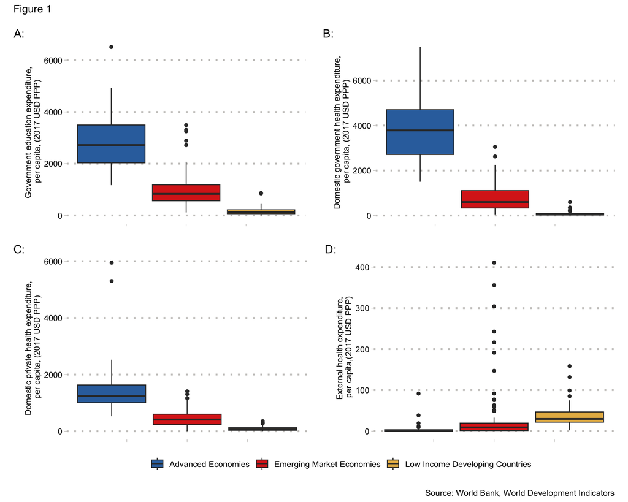

Figure 2 plots per capita health and education expenditure against the HCI+. Several patterns emerge. First, the relationship between spending and human capital is concave: the largest improvements in the HCI+ occur within the first $2,000 per capita in health and education spending, with sharply diminishing returns at higher spending levels.

Figure 2D plots external health expenditure against HCI+ and shows a weak negative relationship. This reflects the targeting of aid toward lower-income countries with weaker human capital outcomes, not a causal effect of external spending on human capital.

[Figure 2 here: Health/education expenditure vs. Human Capital Index]

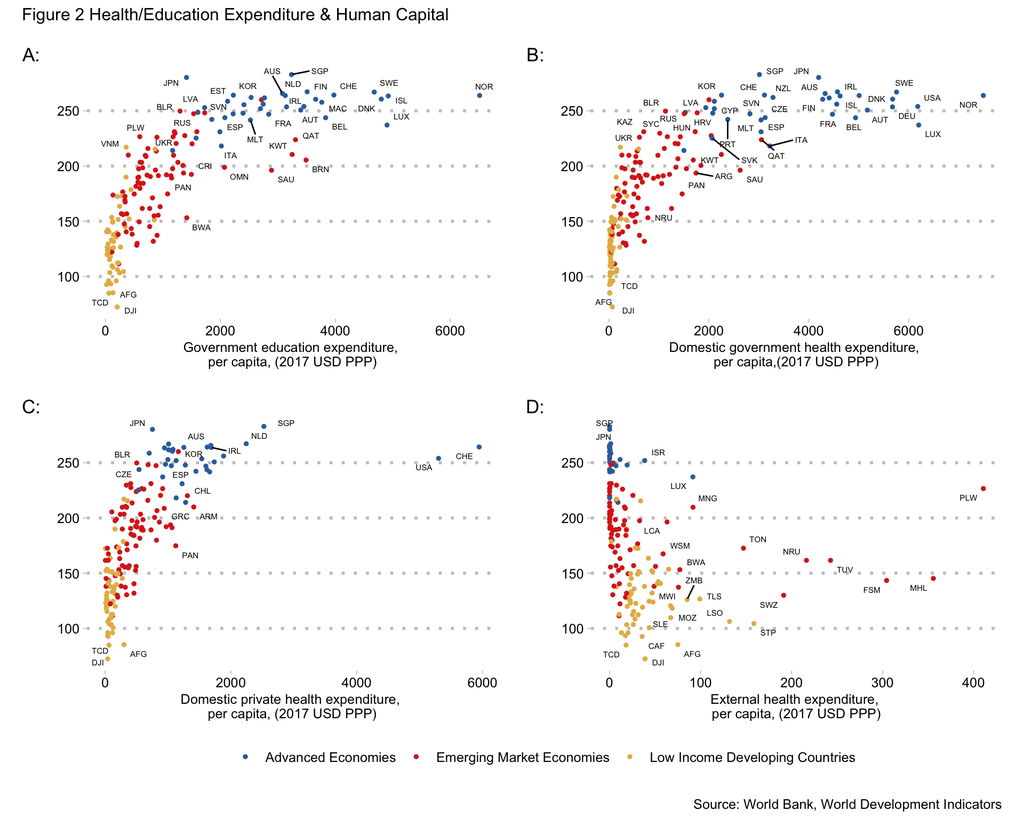

Figure 3 plots the processed data used in the DEA estimation: HCI+ against total health and education expenditure (the four spending categories aggregated). The concave relationship is preserved, with LIDCs clustered at low spending and low outcomes and AEs more dispersed along both dimensions. Countries in the upper-left region of the plot (high human capital relative to spending) approximate the location of the efficiency frontier.

[Figure 3 here: Processed data HCI+ vs. total expenditure]

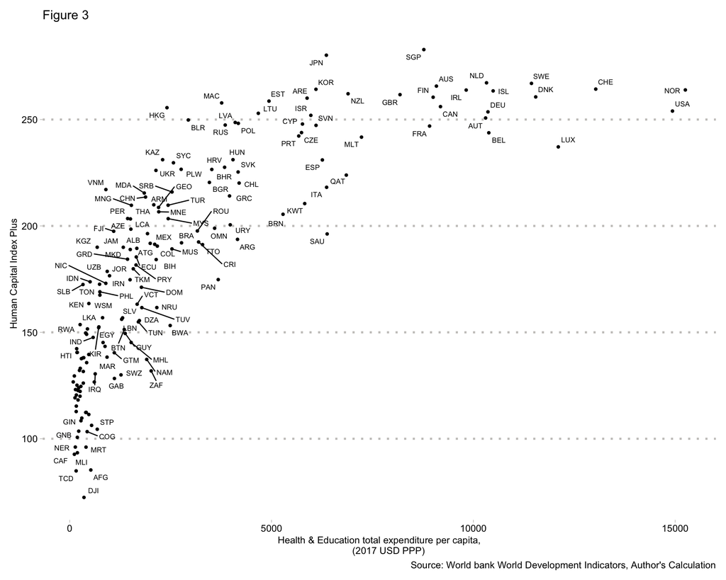

### 3.3 Data Limitations

Several data limitations should be noted. First, the working sample is restricted to countries with complete data across all indicators after listwise deletion. This introduces a potential selection bias: countries with the weakest statistical infrastructure, disproportionately LIDCs and fragile states, are more likely to have missing expenditure or outcome data and are therefore more likely to be excluded. The LIDC subsample may consequently underrepresent the countries where spending efficiency analysis is most policy-relevant and may affect peer group sensitivity.

Second, the quality of government expenditure data varies considerably across income groups. In many LIDCs, public financial management systems may not fully capture all spending channels, off-budget expenditures, or subnational government spending. As a result, expenditure figures for these countries may understate true resource flows, biasing their apparent efficiency upward (achieving observed outcomes with less measured spending than actually occurred) (de Las Casas and Monasterski, 2016). This concern is partially mitigated by the inclusion of external health expenditure, which is typically better documented through donor reporting systems, but it cannot be fully resolved with available data (Mueller et al., 2023).

Third, the Human Capital Index Plus, while a well-constructed composite measure, has its own limitations. The HCI+ reflects expected outcomes for a child born today under current conditions: it is a forward-looking projection of a future worker, not a direct measure of the existing stock of human capital. It also weights its components (survival, schooling, learning, health) according to a specific functional form that may not equally reflect policy priorities across all countries. Additionally, because the HCI+ has relatively limited data coverage, the data points that are averaged are fewer than for the input variables. This coverage mismatch is mitigated by the relative stability of human capital indicators over time, but it represents an imperfect alignment between spending and measured outcomes.

Fourth, GDP per capita enters both as a standalone input and as the resource constraint of the per-capita expenditure measure, introducing a mechanical correlation. This is a common feature of cross-country DEA specifications using per-capita variables (see, e.g., Herrera and Pang, 2005) and reflects the dual role of national income as both a resource base and a conditioning environment for public spending efficiency.

Finally, all cross-country efficiency comparisons assume that the production technology, the process by which spending is converted into human capital, is comparable across countries. In practice, institutional quality, governance (property rights, civil service competence), geographic factors, and disease burden exposure all mediate this relationship in ways that outcome data alone cannot capture. DEA attributes all differences to “inefficiency,” but some portion of the measured efficiency gap likely reflects structural constraints rather than actionable policy failures. This is a known limitation of cross-country DEA (Afonso et al., 2005) and reinforces the paper’s broader argument that point estimates of efficiency should be interpreted with caution, and act as a conversation starter with country authorities.

## 4. Methodology

This section describes the components of the empirical approach: the DEA model specification and the two-level bootstrap procedure for assessing peer group sensitivity. It also outlines the additional peer group sensitivity analysis conducted to validate the main findings.

### 4.1 Data Envelopment Analysis

Data Envelopment Analysis is a non-parametric method for evaluating the relative efficiency of decision-making units (DMUs) that convert multiple inputs into multiple outputs. Originally proposed by Charnes, Cooper, and Rhodes (1978) under constant returns to scale (CRS), and extended by Banker, Charnes, and Cooper (1984) to allow variable returns to scale (VRS), DEA constructs a piecewise-linear frontier over the observed data. Units operating on this frontier receive an efficiency score of 1; units below it receive scores less than 1 that reflect their distance from the frontier.

I adopt an output-oriented VRS specification with two inputs, total health and education expenditure per capita (2017 USD PPP) and GDP per capita (2017 USD PPP), and one output, the Human Capital Index Plus. Output orientation asks how much a country’s human capital outcomes could improve if it matched the performance of its most efficient peers, given its current spending levels. The concave relationship between spending and outcomes documented in Section 3.2 motivates VRS over constant returns to scale.

**Formal Specification of the DEA Model**

For each country (decision-making unit) $o = 1, \dots, n$, the output-oriented variable returns to scale (VRS) DEA model solves the following linear program:

$$\max_{\phi_o, \, \boldsymbol{\lambda}} \quad \phi_o$$
subject to:

$$\sum_{j=1}^{n} \lambda_j \, x_{ij} \leq x_{io}, \quad i = 1, \dots, m$$

$$\sum_{j=1}^{n} \lambda_j \, y_{rj} \geq \phi_o \, y_{ro}, \quad r = 1,
\dots, s$$

$$\sum_{j=1}^{n} \lambda_j = 1$$

$$\lambda_j \geq 0, \quad j = 1, \dots, n$$

where $x_{ij}$ denotes the $i$-th input of country $j$ and $y_{rj}$ denotes the $r$-th output of country $j$. The scalar $\phi_o \geq 1$ represents the maximal proportional expansion of country $o$’s outputs achievable under the technology defined by the convex hull of the observed input–output combinations. The convexity constraint $\sum_j \lambda_j = 1$ imposes variable returns to scale, distinguishing this formulation from the constant returns to scale (CRS) model.

The efficiency score reported throughout this paper is $\theta_o = 1 / \phi_o^*\in (0, 1]$, where $\phi_o^*$ is the optimal value of the program above. A score of $\theta_o = 1$ indicates that country $o$ lies on the efficient frontier; scores below 1 indicate that the country’s observed outputs could be proportionally expanded by a factor of $\phi_o^*$ if it operated as efficiently as its peers.

In the present specification, $m = 2$ inputs (total health and education expenditure per capita in 2017 USD PPP, and GDP per capita in 2017 USD PPP) and $s = 1$ output (the normalized Human Capital Index Plus).

This lean specification of two inputs and one output is deliberate. DEA is subject to dimensionality constraints, which means as the number of inputs and outputs increases relative to the number of DMUs, a larger share of units are classified as efficient simply because there are insufficient peers to dominate them across all dimensions (Dyson et al., 2001). A rule of thumb from Cooper, Seiford, and Tone (2007) requires that the number of DMUs exceed three times the sum of inputs and outputs. With 172 countries in the sample and three total variables, this condition is comfortably satisfied.

A modeling choice worth noting is aggregating four spending categories into a single input variable. This sacrifices the ability to distinguish between countries that allocate heavily to education versus health, or between those relying on domestic versus external financing. The aggregation is motivated by the dimensionality constraint and by this paper’s focus on the sensitivity of overall efficiency scores to peer composition rather than on decomposing the sources of inefficiency across spending categories.

### 4.2 Variable preprocessing

No normalization or rescaling is applied to the input or output variables before DEA estimation. The two inputs (total health and education expenditure per capita and GDP per capita) are expressed in 2017 USD PPP, and the output (HCI+) uses its own continuous scale. DEA is units-invariant: the linear program endogenously assigns the most favorable weights to each input and output for each DMU, so differences in magnitude across variables do not affect the resulting efficiency scores (Cooper, Seiford, and Tone, 2007).

Normalization would be necessary under two circumstances that do not apply here. First, when multiple outputs (or inputs) measured in incompatible units must be aggregated into a composite index before estimation, standardization is required to prevent variables with larger natural scales from dominating the aggregation. Second, when principal component analysis (PCA) is used for dimensionality reduction, Z-score standardization ensures that the principal components reflect the correlation structure of the data rather than arbitrary scale differences. Kapsoli, Mogues, and Verdier (2023), for example, standardize infrastructure output indicators (road kilometers, kWh of electricity per capita, telephone lines per 100 people) before applying PCA to construct a composite output index because variables in heterogeneous units must be reduced to a single dimension.

Z-score normalization applied directly to DEA also raises a specific concern under variable returns to scale. While DEA is invariant to multiplicative rescaling (changes of units), it is not invariant to additive translation under VRS: shifting the data by subtracting the mean, as Z-scoring does, changes the location of observations in input-output space, and the convexity constraint $\sum_j \lambda_j = 1$ interacts with this location, altering the frontier’s geometry and potentially the efficiency scores. A subsequent shift to ensure strict positivity compounds this effect. Under CRS, where the frontier is a cone through the origin, translation invariance is less of a concern, but the VRS specification adopted in this paper is sensitive to it. Moreover, dividing by the standard deviation implicitly imposes equal variance-based weighting across variables, overriding DEA’s capacity to endogenously determine the most favorable weighting for each DMU.

Because the variables in this analysis are in common units, do not require complex aggregation, and the DEA specification operates under VRS, raw values are used throughout. The only preprocessing applied is replacing any exact zeros with 0.0001 to satisfy DEA’s strict positivity requirement.

### 4.3 The Two-Level Bootstrap Procedure

The procedure addresses two sources of uncertainty that are relevant for applied cross-country DEA but have not previously been combined. Estimation uncertainty, addressed by the Simar-Wilson bootstrap, asks: given a fixed set of comparator countries, how precisely can efficiency scores be estimated? Peer group uncertainty asks a different question: how much do efficiency scores change when the set of comparators itself changes?

These two sources require different perturbations because they operate on different features of the frontier. The Simar-Wilson bootstrap resamples efficiency scores with replacement, applies kernel smoothing and reflection at the boundary of 1, and radially repositions observations using the resulting pseudo-scores. This preserves the frontier’s geometry: every bootstrap replicate has the same n countries at the same angles in input-output space, with only their radial distances perturbed. The frontier’s facet structure, which countries are neighbors, which anchor each segment, remains unchanged (invariant) across replicates.

Peer group subsampling in the outer loop breaks this invariance. Excluding a frontier-defining country removes the facet it anchors. A different segment of the piecewise-linear frontier becomes binding for remaining countries, producing a discrete shift in their scores rather than the continuous perturbation generated by the inner bootstrap. The multimodal distributions documented in Section 5 confirm that these are qualitatively different phenomena.

The procedure nests one perturbation inside the other, as follows.

#### **Algorithm 1:** Two-level bootstrap for DEA efficiency-score sensitivity

**Input:** Country data $\mathcal{D} = \{(\mathbf{x}_j, \mathbf{y}_j)\}_{j=1}^{n}$; outer iterations $B = 10{,}000$; inner replications $R = 100$; subsample fraction $p = 0.7$; RNG seed $\sigma = 321$.

**Output:** Empirical distribution $\mathcal{F}_o$ of bias-corrected efficiency scores for each country $o$.

| Line | Step |
| --- | --- |
| 1: | Set RNG seed to $\sigma$ |
| 2: | Initialize $\mathcal{F}_o \leftarrow \emptyset$ for $o = 1, \dots, n$ |
| 3: | **for** $b = 1$ **to** $B$ **do** |
| 4: | $\quad$ *// Outer level: peer-group subsampling* |
| 5: | $\quad$ Draw $S_b \subset \{1, \dots, n\}$ with $\lvert S_b \rvert = \lfloor p\,n \rfloor$, without replacement |
| 6: | $\quad$ *// Inner level: Simar–Wilson bias correction on $S_b$* |
| 7: | $\quad$ **for each** $o \in S_b$ **do** |
| 8: | $\quad\quad$ Solve the output-oriented VRS LP for $o$ against the frontier defined by $S_b$ |
| 9: | $\quad\quad$ Obtain $\hat{\phi}_o^{(b)\,*}$ and set $\hat{\theta}_o^{(b)} \leftarrow 1 / \hat{\phi}_o^{(b)\,*}$ |
| 10: | $\quad$ **end for** |
| 11: | $\quad$ Apply Simar–Wilson (1998) bootstrap with $R$ replications to obtain $\{\tilde{\theta}_o^{(b)}\}_{o \in S_b}$ and 95% CIs |
| 12: | $\quad$ **for all** $o \in S_b$ **do** |
| 13: | $\quad\quad$ $\mathcal{F}_o \leftarrow \mathcal{F}_o \cup \{\tilde{\theta}_o^{(b)}\}$ |
| 14: | $\quad$ **end for** |
| 15: | **end for** |
| 16: | **return** $\{\mathcal{F}_o\}_{o=1}^{n}$ |

**Outer level: peer group subsampling.** In each $b$ of 10,000 iterations, a fixed subsample of approximately $\lfloor pn \rfloor$ of the observed countries are drawn without replacement from the full dataset, where $p = [0.6/0.7/0.8/0.9]$. This changes the composition of the peer group and, consequently, the shape of the efficiency frontier against which all included countries are evaluated. Drawing countries without replacement also provides precise control over the exclusion rate, which can then be varied systematically as part of the peer group perturbation.

**Inner level: Simar-Wilson bias correction.** Within each subsampled peer group, DEA is estimated using the bootstrap procedure of Simar and Wilson (1998), as implemented in the Benchmarking R package’s `dea.boot` function with 100 replications. This inner bootstrap resamples efficiency scores with replacement and applies a reflection procedure to construct bias-corrected efficiency estimates and 95 percent confidence intervals for the subsample. Simar and Wilson (2000b) recommend about 1,000 replications for the inner bootstrap. The lower count of 100 used here reflects the computational cost of the two-level procedure: 10,000 outer iterations at 100 inner replications yield approximately 1,000,000 total DEA estimates. The inner-loop noise could in principle inflate apparent multimodality in the outer distributions. The persistence of multimodality at 90% retention, where outer-loop variation is minimal (Section 5.2.1), provides indirect evidence against this concern, but a direct validation using higher inner replication counts on a subset of countries would strengthen the finding.

**Output.** For each country, the procedure yields a distribution of up to 10,000 bias-corrected efficiency scores (fewer for any given country, since each appears in approximately $pB$ subsamples). Summary statistics characterize central tendency and dispersion, but as Section 5 demonstrates, these can be misleading when distributions are multimodal. The full distributional shape is therefore the primary object of interest.

The random number generator seed is set to 321 prior to the simulation. All analysis is conducted in R using the Benchmarking package (Bogetoft and Otto, 2011).

### 4.4 Interpretation of the Robustness Distributions

The distributions produced by the outer loop are peer group sensitivity intervals, not confidence intervals for a population parameter in the Simar-Wilson sense. They show the range of efficiency scores a country receives under different peer group compositions. A tight interval indicates that the score is robust to sample changes; a wide or multimodal interval indicates that the score depends substantially on which countries are included. This distinction, however, matters for interpretation. When a country’s sensitivity distribution shows two modes, this does not indicate estimation error around a true score lying between them. It indicates that the country sits near a junction between structurally distinct frontier segments. Under one peer group, a particular facet is binding and the country appears relatively inefficient; under another, where a key frontier country is absent, a different facet binds and the same country appears more efficient. Both scores are valid for their respective peer groups, and DEA provides no criterion to prefer one over the other.

The inner Simar-Wilson bootstrap maintains the standard assumption of a true production possibility set with i.i.d. draws (Simar and Wilson, 1998; Kneip, Park, and Simar, 1998). The outer loop makes no such claim. It is a sensitivity exercise: each subsample represents an alternative comparator group that an analyst with different data availability or regional focus might have assembled. If the underlying production technology is heterogeneous across income groups, as Section 3 suggests, some of the observed multimodality may reflect structural differences in the data generating process rather than pure frontier reconfiguration. The procedure cannot distinguish these two sources, which reinforces its interpretation as a diagnostic tool rather than an inferential one. The sensitivity distribution does not yield a “truer” point estimate. Rather, it yields a characterization of what DEA can and cannot tell the analyst about a given country. The two levels of the procedure therefore have distinct uses: the inner loop estimates, and the outer loop diagnoses.

### 4.5 Distributional Classification and Diagnostic Extensions

**Varying the subsampling share and Formal multimodality testing.** While the baseline analysis draws 70 percent of countries in each iteration, I also repeat the procedure at subsampling rates of 60, 80, and 90 percent. If multimodal patterns remain at 90%, it shows instability isn’t due to aggressive subsampling but sensitivity to peer changes. If instability lessens at higher retention, it indicates how much peer variation causes score shifts. To assess whether each country’s score distribution is unimodal or multimodal, I apply Hartigan’s dip test (Hartigan and Hartigan, 1985) to the bootstrapped efficiency scores at each subsampling rate. The dip statistic measures the maximum difference between the empirical distribution function and the best-fitting unimodal distribution; the null hypothesis is unimodality, rejected at p<0.05. Testing across all subsample shares establishes whether the multimodal structures are a stable feature of the distributions or emerge only at lower subsample rates.

**Distributional typology.** Countries are classified into three types by combining the dip test with Gaussian mixture model (GMM) selection. For each country, I fit GMMs with 1 to 5 components and select the best-fitting model by BIC (Fraley and Raftery, 2002; mclust R package). The typology is assigned as follows: Concentrated if the dip test does not reject unimodality and BIC selects one component; Discrete multimodal if the dip test rejects unimodality and BIC selects 2–3 components; Diffuse multimodal if BIC selects 4 or more components or the distribution exhibits wide spread without sharp density valleys.

**Leave-one-out influence analysis.** For each country that appears on or near the efficiency frontier in the baseline DEA (the full-sample, single-run estimate), I re-estimate the model without that country and record the resulting changes in efficiency scores for all remaining countries. This identifies “influential peers,” frontier countries whose inclusion or exclusion causes discrete shifts in other countries’ scores, and directly tests the hypothesized mechanism that generates the multimodal distributions observed in the main results.

**Within-income-group subsampling.** Rather than drawing from the full cross-country sample, I conduct subsampling within each income group (AEs, EMEs, LIDCs). This tests if instability mainly results from mixing different economy types, violating homogeneity, or if scores are sensitive to peer composition among broadly comparable countries.

**Alternative DEA specifications.** I re-run the bootstrap under two alternative specifications: (i) constant returns to scale (CRS) instead of VRS, and (ii) input instead of output orientation. If key patterns, such as higher instability for LIDCs and multimodal distributions persist, the findings are robust. If not, it shows which results depend on the specification.

## 5. Application to Cross-Country Human Capital Spending

This section presents the main findings in three parts. Section 5.1 reports aggregate efficiency scores and the distributional shape of individual countries’ efficiency scores, focusing on the prevalence and implications of multimodality. Section 5.2 presents the robustness checks and diagnostic extensions.

### 5.1 Peer Group perturbation’s Distributional Typology

Figure 4A shows mean efficiency scores for the baseline 70% subsample, by income group: AEs score highest, followed by EMEs, then LIDCs, consistent with prior research (Herrera and Pang, 2005; Afonso et al., 2005). Figure 4B plots the standard deviation of each country’s score distribution across the 10,000 iterations. Mean standard deviations are nearly identical across income groups: 0.022 for LIDCs, followed by AEs (0.021) and EMEs (0.020). By this measure, peer group sensitivity appears to be a uniform phenomenon.

This uniformity is misleading. A standard deviation of 0.021 can reflect a tight unimodal distribution or a bimodal distribution with two modes separated by a density valley. Aggregate dispersion statistics cannot distinguish between a country whose score is measured with moderate noise around a single value and one whose score switches between two distinct values depending on which peers are included. Both the distributional shape and the spread, matters.

[Figure 4 here: Mean efficiency scores (4A) and standard deviation of efficiency scores (4B) by income group]

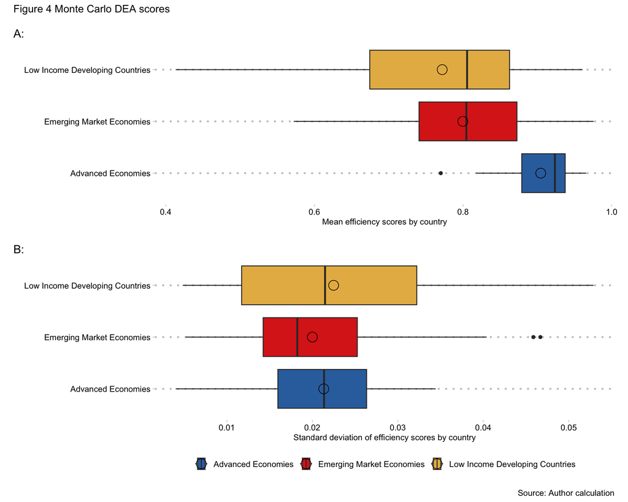

Table 1 classifies the 172 countries into three types based on the dip test and GMM/BIC procedure described in Section 4.5.

[Table 1: Distributional Typology of Bootstrap Efficiency Score Distributions]

Distributional typology of bootstrap efficiency score distributions, by income group. Counts shown as N (percent within row).

| Income Group | Concentrated | Discrete (2–3 modes) | Diffuse (4+ modes) |
| --- | --- | --- | --- |
| Advanced Economies | 1 (2.8%) | 32 (88.9%) | 3 (8.3%) |
| Emerging Market Economies | 3 (3.7%) | 54 (66.7%) | 24 (29.6%) |
| Low Income Developing Countries | 15 (27.3%) | 32 (58.2%) | 8 (14.5%) |
| Total | 19 (11.0%) | 118 (68.6%) | 35 (20.3%) |

The three types have distinct interpretive implications.

[Figure 5: Bootstrap score distributions for exemplar countries by typology]

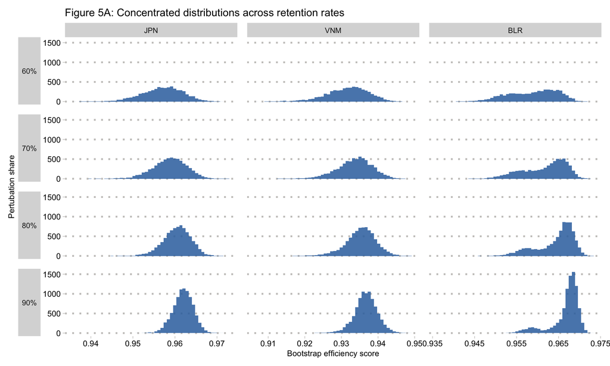

**Discrete multimodal distributions** (118 countries, 68.6 percent) exhibit two or three well-separated modes with density valleys between them. For these countries, the majority of the sample, the mean efficiency score falls in a region of low density and represents a value the country rarely receives. AEs cluster overwhelmingly in this category (88.9%), reflecting mode-switching driven by the inclusion or exclusion of specific frontier peers (identified in Section 5.2.2).

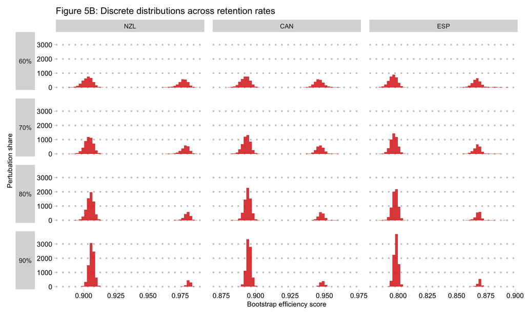

**Diffuse multimodal distributions** (35 countries, 20.3 percent) exhibit four or more modes or wide spreads without sharp density valleys. The mean falls in a positive-density region and is therefore not as positionally misleading, but it is imprecise. An interval estimate would be more informative than a point estimate. EMEs are disproportionately represented (29.6%). At 60% retention, the distribution is dispersed, with multiple low-density modes resembling a plateau. As retention increases, the distribution consolidates: a dominant mode emerges, and satellite modes shrink. By 90% retention, many countries show a bimodal pattern: a tall primary spike and small secondary bumps. This indicates that the diffuse category depends partly on how many countries are excluded, not just on a country’s position.

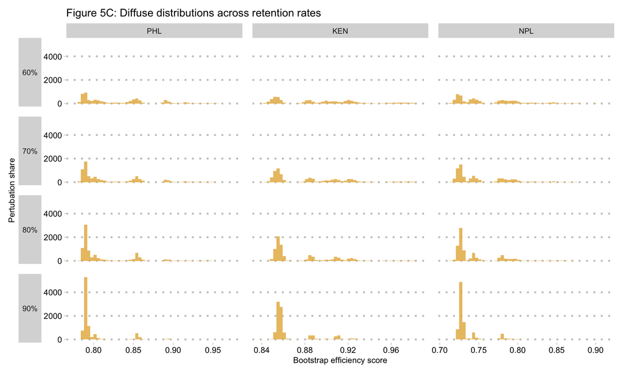

The three categories respond differently to changes in perturbation intensity. Concentrated distributions narrow but stay unimodal. Discrete ones sharpen around a primary mode but keep a secondary mode. Diffuse distributions gradually shift from a plateau to a discrete form. These responses suggest the typology reflects distinct mechanisms, not thresholds, with the boundary between Discrete and Diffuse categories forming a continuum. Countries with several frontier segments show discrete modes, while those with many weak peers have diffuse variation that becomes discrete when perturbation lessens.

### 5.2 Robustness Checks and Diagnostic Extensions

This section presents the results of robustness checks intended to validate the main observations and identify the mechanisms underlying the observed instability and multimodality.

#### 5.2.1 Sensitivity to Subsampling Share and Formal Multimodality Testing

The baseline analysis draws 70 percent of countries in each iteration. Table 2 compares the mean standard deviation of efficiency scores across income groups at subsampling rates of 60, 80, and 90 percent.

[Table 2: Mean Standard Deviation of Efficiency Scores by Income Group and Subsampling Share]

Mean / median SD of efficiency scores by income group and subsampling share

| Income Group | 60% | 70% (baseline) | 80% | 90% |
| --- | --- | --- | --- | --- |
| Advanced Economies | 0.023 / 0.023 | 0.021 / 0.021 | 0.018 / 0.018 | 0.014 / 0.014 |
| Emerging Market Economies | 0.023 / 0.021 | 0.020 / 0.018 | 0.016 / 0.015 | 0.011 / 0.010 |
| Low Income Developing Countries | 0.027 / 0.027 | 0.022 / 0.021 | 0.018 / 0.015 | 0.012 / 0.011 |

Score dispersion, measured by standard deviation, decreases monotonically as the retention rate increases (Table 2). This is expected: at 90% retention, about 17 countries are excluded per draw, causing smaller shifts in the frontier. The rate of decrease, however, is informative.

At 60 percent subsampling share, LIDCs show the highest mean standard deviation (0.027), followed by AEs and EMEs (0.023). As retention rises, this gap narrows. At 90%, AEs have 0.014 compared to LIDCs at 0.012, reversing the trend. This illustrates that solely relying on standard deivation as a measure of peer group sensitivity misses distributional typology.

The key finding is the persistence of dispersion at 90% retention. Even excluding about 17 countries (10% of the sample) shifts the efficiency frontier, indicating that small sample changes, which might arise from minor shifts in data coverage, can significantly affect DEA results. To further test the multimodal patterns documented in Section 5.1, I applied Hartigan’s dip test (Hartigan and Hartigan, 1985) to each country’s score distribution at each subsampling share to formally assess the null hypothesis of unimodality.

Of 172 countries with sufficient observations for testing, 153 (89.0 percent) exhibited statistically significant multimodality at the 5 percent level, and 153 (89.0 percent) at the 1 percent level.

Table 3 Multimodality Prevalence by Income Group and Subsample Share (p < 0.05), shows that multimodality is pervasive and stable across rates: over 96 percent percent of countries in AEs and EMEs show significant multimodality at all retention rates, with minimal change between 60 and 90 subsampling shares.

[Table 3: Multimodality Prevalence by Income Group and Subsample Share (p < 0.05)]

Multimodality prevalence by income group and retention rate (p < 0.05)

| Income Group | 60% | 70% | 80% | 90% |
| --- | --- | --- | --- | --- |
| Advanced Economies | 35 / 36 (97.2%) | 35 / 36 (97.2%) | 35 / 36 (97.2%) | 35 / 36 (97.2%) |
| Emerging Market Economies | 78 / 81 (96.3%) | 78 / 81 (96.3%) | 78 / 81 (96.3%) | 79 / 81 (97.5%) |
| Low Income Developing Countries | 40 / 55 (72.7%) | 40 / 55 (72.7%) | 40 / 55 (72.7%) | 38 / 55 (69.1%) |

The top 15 most multimodal countries at the 90 percent retention rate are dominated by AEs and EMEs: Kazakhstan (dip statistic 0.062), Latvia (0.056), and Montenegro (0.051), etc. All 15 yield dip test p-values of effectively zero. Notably, many are not outlier economies at the extremes of the input-output space; most are mid-ranked countries with mean efficiency scores in the 0.70–0.90 range, occupying the region where multiple frontier segments compete to define the reference technology. Their multimodal structure remains even when only 10% of the sample is altered, highlighting how little variation is needed to cause discrete score jumps among countries near the frontier intersection.

[Table 4: Top 15 Most Multimodal Countries at 90% Subsample Share]

Top 15 most multimodal countries at the 90 percent subsample share, ranked by dip-test p-value (dip statistic as tiebreaker).

| Country | Income group | Mean score | SD | Dip statistic | p-value |
| --- | --- | --- | --- | --- | --- |
| KAZ | Emerging Market Economies | 0.931 | 0.011 | 0.062 | <0.001 |
| LVA | Advanced Economies | 0.937 | 0.010 | 0.056 | <0.001 |
| MNE | Emerging Market Economies | 0.851 | 0.011 | 0.051 | <0.001 |
| GRC | Advanced Economies | 0.810 | 0.009 | 0.051 | <0.001 |
| MEX | Emerging Market Economies | 0.795 | 0.011 | 0.048 | <0.001 |
| URY | Emerging Market Economies | 0.768 | 0.006 | 0.048 | <0.001 |
| RUS | Emerging Market Economies | 0.939 | 0.009 | 0.047 | <0.001 |
| ATG | Emerging Market Economies | 0.796 | 0.011 | 0.046 | <0.001 |
| HUN | Emerging Market Economies | 0.873 | 0.009 | 0.046 | <0.001 |
| IDN | Emerging Market Economies | 0.918 | 0.016 | 0.045 | <0.001 |
| NZL | Advanced Economies | 0.914 | 0.023 | 0.044 | <0.001 |
| AUS | Advanced Economies | 0.934 | 0.016 | 0.043 | <0.001 |
| PRT | Advanced Economies | 0.874 | 0.018 | 0.043 | <0.001 |
| ESP | Advanced Economies | 0.805 | 0.021 | 0.043 | <0.001 |
| DEU | Advanced Economies | 0.893 | 0.014 | 0.042 | <0.001 |

#### 5.2.2 Leave-One-Out Influence Analysis

The peer group perturbation reveals widespread multimodality but cannot identify which frontier countries drive the mode-switching. The leave-one-out analysis (Wilson, 1995; Pastor, Ruiz, and Sirvent, 1999) addresses this by re-estimating the full-sample DEA excluding each frontier country and recording the resulting score changes for all remaining countries.

[Table 5: Most Influential Frontier Countries]

Most Influential Frontier Countries

| Rank | Country | Mean Δ when excluded | Countries affected | Max single impact |
| --- | --- | --- | --- | --- |
| 1 | SLB | 0.011 | 45 | 0.099 |
| 2 | VNM | 0.011 | 53 | 0.073 |
| 3 | JPN | 0.010 | 43 | 0.063 |
| 4 | BLR | 0.003 | 27 | 0.023 |
| 5 | HKG | 0.001 | 4 | 0.024 |

Three countries are substantially more influential than all others. Solomon Islands, when excluded, shifts the mean score of remaining countries by 0.011 points, with a maximum single-country impact of 0.099 points and 45 countries affected. Vietnam is similarly influential, (mean score shift of 0.011 points, maximum impact of 0.073 points, and 53 countries affected). Japan completes the set (mean score shift of 0.010 points, maximum shift of 0.063 points, 43 countries affected). Beyond these three, influence drops sharply: the fourth-ranked country, Belarus, produces a mean shift of only 0.003 points, and Hong Kong, the fifth-ranked frontier country, shifts scores by just 0.001 points on average with only 4 countries materially affected.

The low measured influence of Hong Kong (mean shift 0.001, 4 countries affected) is partly an artifact of the leave-one-out design: Japan remains in every subsample that excludes Hong Kong, anchoring the same frontier segment. The subsampling procedure, which can exclude both simultaneously, captures these interactive effects.

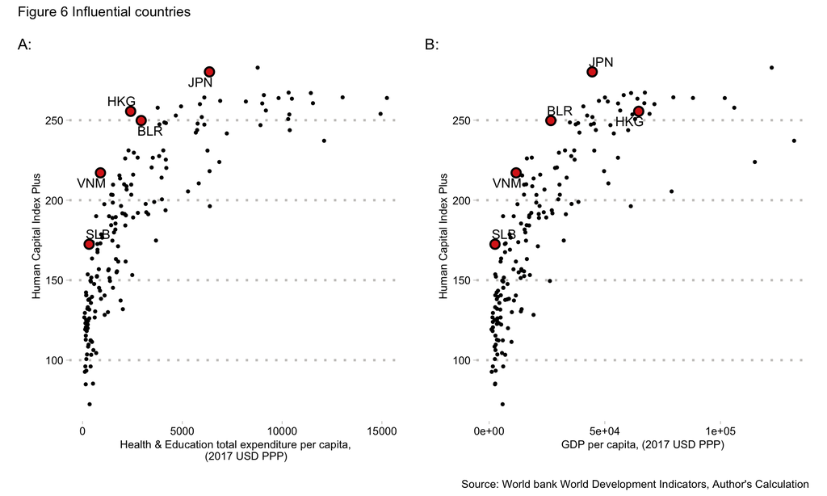

This finding underscores the complementary value of the two diagnostics. The leave-k-out procedure reveals that discrete mode-switching exists but it cannot isolate the responsible peers. The leave-one-out analysis identifies the anchor countries. Together, they show not only that peer group sensitivity is structured rather than random, but that the structure traces to a small number of identifiable frontier features.

[Table 6: Countries Most Affected by Frontier Peer Exclusion]

Countries Most Affected by Frontier Peer Exclusion

| Rank | Country | ISO | Income Group | Region | Mean Δ | SD Δ | Range Δ |
| --- | --- | --- | --- | --- | --- | --- | --- |
| 1 | Kiribati | KIR | Low Income Developing Countries | Emerging and Developing Asia | 0.010 | 0.031 | 0.099 |
| 2 | Lesotho | LSO | Low Income Developing Countries | Sub-Sahara Africa | 0.007 | 0.024 | 0.075 |
| 3 | Fiji | FJI | Emerging Market Economies | Emerging and Developing Asia | 0.007 | 0.023 | 0.073 |
| 4 | Burkina Faso | BFA | Low Income Developing Countries | Sub-Sahara Africa | 0.007 | 0.022 | 0.071 |
| 5 | Vanuatu | VUT | Emerging Market Economies | Emerging and Developing Asia | 0.007 | 0.020 | 0.065 |
| 6 | Afghanistan | AFG | Low Income Developing Countries | Middle East, North Africa, Afghanistan, and Pakistan | 0.006 | 0.020 | 0.064 |
| 7 | New Zealand | NZL | Advanced Economies | Advanced Economies | 0.006 | 0.020 | 0.063 |
| 8 | Micronesia | FSM | Emerging Market Economies | Emerging and Developing Asia | 0.006 | 0.019 | 0.061 |
| 9 | Tajikistan | TJK | Low Income Developing Countries | Caucasus and Central Asia | 0.006 | 0.019 | 0.061 |
| 10 | Slovenia | SVN | Advanced Economies | Advanced Economies | 0.006 | 0.019 | 0.060 |

The countries most affected by anchor peer exclusion are disproportionately LIDCs and small island EMEs (Table 6). Kiribati exhibits the largest score range (0.099), followed by Lesotho (0.075), Fiji (0.073), and Burkina Faso (0.071). Two Advanced Economies, New Zealand and Slovenia, also appear among the top 10, indicating that peer sensitivity is not exclusively a developing-country phenomenon, though the largest magnitudes remain concentrated among LIDCs and small island EMEs.

#### 5.2.3 Within-Income-Group Subsampling

A common recommendation in applied cross-country DEA is to restrict comparator groups to income-group peers, improving homogeneity at the cost of a smaller sample. To test whether this resolves the instability documented above, I repeated the bootstrap procedure separately within each income group.

[Table 7: Mean Standard Deviation of Efficiency Scores — Full Sample vs. Within-Income-Group Frontiers]

Full-sample vs within-income-group frontiers: dispersion and multimodality

[output not shown]

The results are mixed. For EMEs, within-group benchmarking reduces the mean standard deviation from 0.020 under the full-sample frontier to 0.014, a 31 percent reduction. This observation is consistent with the hypothesis that removing structurally dissimilar AEs from the frontier may improve stability. For AEs and LIDCs, however, within-group instability is marginally higher than under the full-sample frontier (0.023 vs. 0.021 for AEs; 0.025 vs. 0.022 for LIDCs). This potentially reflects a competing effect: restricting the comparator group improves homogeneity but also reduces the number of DMUs defining the frontier, making it more sensitive to the inclusion or exclusion of any single peer.

EMEs (81 countries) retain enough peers for the homogeneity benefit to dominate. AEs (36 countries) and LIDCs (55 countries) do not.

Furthermore, the multimodality results show that for AEs, multimodality prevalence is identical under both frontiers (97.2 percent), indicating that the mode-switching documented in Section 5.1 is driven by interactions among AE peers themselves rather than by the presence of structurally dissimilar EMEs or LIDCs. For EMEs, by contrast, multimodality prevalence drops sharply from 96.3 percent under the full-sample frontier to 72.8 percent under the within-group frontier. This suggests that a substantial share of EME mode-switching is driven by cross-group frontier peers, likely Japan and Hong Kong, whose inclusion or exclusion reconfigures the frontier segments relevant to EME evaluation. For LIDCs, multimodality prevalence is marginally higher under the within-group frontier (74.5 percent vs. 72.7 percent), consistent with the thinner frontier producing additional instability that offsets the homogeneity gains.

The practical implication is that restricting comparator groups to income-group peers does not necessasrily resolve peer group sensitivity and may exacerbate it for smaller groupings. The choice between a broad and a narrow comparator group involves a trade-off between homogeneity and frontier density, with neither option dominating. Practitioners should analyze results under different configurations and interpret differences in light of the sample size available for each.

#### 5.2.4 Alternative DEA Specifications

To test whether the key findings are robust to other DEA modeling choices, I re-ran the full two-level bootstrap under two alternative specifications: constant returns to scale with an output orientation (CRS output) and variable returns to scale with an input orientation (VRS input).

Table 8 reports the results.

[Table 8: Mean Standard Deviation by Income Group Across DEA Specifications]

Mean SD and multimodality prevalence by income group and DEA specification

| Income Group | VRS output (baseline) | CRS output | VRS input |
| --- | --- | --- | --- |
| Advanced Economies | 0.021 (97.2%) | 0.007 (100%) | 0.056 (91.7%) |
| Emerging Market Economies | 0.020 (96.3%) | 0.017 (100%) | 0.057 (97.5%) |
| Low Income Developing Countries | 0.022 (72.7%) | 0.057 (96.4%) | 0.053 (87.3%) |

The specifications differ in dispersion levels, however, in ways that are informative about the baseline choice. VRS-input produces roughly three times the instability of VRS-output across all income groups (mean SDs of 0.053–0.057 vs. 0.02–0.022). This likely reflects the concavity documented in Section 3.2: input orientation asks by how much spending could be reduced while maintaining outcomes, and in the diminishing-returns region where AEs operate, small frontier shifts translate into large input-contraction estimates. Output orientation produces smaller proportional shifts because the HCI+ is already near its upper bound for high-spending countries.

CRS output produces lower absolute variability but implausible scores. AEs that score 0.80–0.95 under VRS receive scores below 0.05 under CRS, which is not an efficiency finding but a specification failure. The constant-returns frontier extrapolates the input-output ratios of small, high-performing countries like Solomon Islands linearly to AE spending levels, implying frontier outputs that no country achieves.

While the AE standard deviation seems low (0.007), it is misleading relative to mean scores of approximately 0.04.

## 6. Discussion and Policy Implications

The standard output of a cross-country DEA exercise is a table of point estimates, often presented as a ranked list with an implicit assumption that the scores reflect durable features of spending efficiency. The instability documented in this paper challenges that assumption, and asks, can the same country, evaluated under slightly different peer group compositions, receive efficiency scores that would support qualitatively different policy recommendations? This section discusses the implications and situates the findings within the broader debate about benchmarking methods in public economics.

### 6.1 A Practical Recommendation

The practical response is straightforward. Practitioners conducting cross-country DEA should, at minimum, report distributional results alongside point estimates. Appendix Table 2 illustrates the proposed format, which differs from the standard DEA results table only by the addition of a single 10th-to-90th percentile score range column from the peer group pertubation. This interval characterizes how much a country’s efficiency score varies as the comparator group changes, providing the reader with an immediate sense of how much weight the point estimate can bear.

Where the range is narrow, as for Japan (0.95–0.96) or Singapore (0.94–0.98), the point estimate can anchor policy discussion with confidence. Where it is wider, as for Kiribati (0.82–0.95) or Tajikistan (0.74–0.84), the score should be treated as indicative, and the width of the interval is itself informative. For countries exhibiting discrete multimodality, which this analysis finds to be the majority, the modal scores and their associated peer configurations can be informative as part of the sensitivity exercise.

### 6.2 Multimodality as a Diagnostic

For policy analysts, multimodality should also be treated as a diagnostic. When a country’s score distribution shows two well-separated modes, the natural next step is to identify which frontier peers drive the discrete jump, using leave-one-out analysis, and to assess whether those peers are genuinely comparable. This transforms the DEA exercise from a ranking tool into a structured investigation of which comparisons are driving the result, a more transparent and ultimately more useful output for policy audiences.

### 6.3 Implications for Peer Group Selection

More broadly, the choice of comparator group should be treated as a modeling decision, reported transparently and tested for sensitivity. In institutional practice, this choice is often set by convention, income-group aggregates, regional groupings, or established peer lists, which travel across analyses with minimal adjustment. The findings here suggest that two similarly defensible assessments of the same country, differing only in their peer-group convention, can yield different efficiency rankings.

This recommendation echoes a broader point in the benchmarking literature. Just as a difference-in-differences estimate is only as credible as its control group, a DEA efficiency score is only as meaningful as its comparator set. The peer group perturbation procedure provides a structured way to assess this credibility.

### 6.4 Limitations of the Approach

Several limitations of the present analysis should be acknowledged. First, the subsampling procedure treats all countries as equally likely to be included or excluded; in practice, major economies or countries with stronger statistical reporting standards are more likely to appear in any given analysis, and the relevant variation is in the periphery of the sample. A more targeted sensitivity analysis, varying only the countries whose inclusion may be less likely, might be more directly relevant for applied work but would require analyst-specific input on sample construction. Second, the procedure characterizes sensitivity but does not resolve it; knowing a country’s score ranges from 0.75 to 0.95 is more informative than the mean alone, but it does not indicate which score is correct. Third, the analysis also uses large cross-sectional averages; extending the group perturbation procedure to panel DEA settings is a natural direction for further work. Finally, the lean two-input, one-output specification was chosen to maximize the number of peers, but richer specifications with different variable selections may produce different sensitivity patterns.

### 6.5 Concluding thoughts

These recommendations should not reduce or diminish DEA’s value as a benchmarking tool. DEA remains one of the few methods for systematically comparing spending efficiency across countries without imposing a parametric production function. The contribution of this paper is to show that the tool’s output should be accompanied by the information needed to interpret it responsibly.

## References

Afonso, A., Schuknecht, L., and Tanzi, V. (2005). “Public Sector Efficiency: An International Comparison.” *Public Choice*, 123(3–4), 321–347.

Afonso, A., Schuknecht, L., and Tanzi, V. (2006). “Public Sector Efficiency: Evidence for New EU Member States and Emerging Markets.” ECB Working Paper No. 581. Frankfurt: European Central Bank.

Afonso, A., Romero, A., and Monsalve, E. (2013). “Public Sector Efficiency: Evidence for Latin America.” IDB Discussion Paper No. IDB-DP-279. Washington, DC: Inter-American Development Bank.

Afonso, A., and Kazemi, M. (2017). “Assessing Public Spending Efficiency in 20 OECD Countries.” In B. Bökemeier and A. Greiner (Eds.), *Inequality and Finance in Macrodynamics* (pp. 7–42). Cham: Springer.

Afonso, A. & Baquero Fraga, G. (2024). “Government spending efficiency in Latin America.” Empirica, 51(1), 127–160.

Ahmed, S., Hasan, M. Z., MacLennan, M., Dorin, F., Ahmed, M. W., Hasan, M. M., Hasan, S. M., and Khan, J. A. M. (2019). “Measuring the Efficiency of Health Systems in Asia: A Data Envelopment Analysis.” *BMJ Open*, 9(3), e022155.

Aristovnik, A. (2012). “The Relative Efficiency of Education and R&D Expenditures in the New EU Member States.” *Journal of Business Economics and Management*, 13(5), 832–848.

Aristovnik, A., and Obadić, A. (2014). “Measuring Relative Efficiency of Secondary Education in Selected EU and OECD Countries: The Case of Slovenia and Croatia.” *Technological and Economic Development of Economy*, 20(3), 419–433.

Amakoue, P., and Diallo, A. (2026). “Public Health Spending Efficiency in Sub-Saharan African Countries: How to Deal with Public Debt and Fiscal Deficit?” *Journal of International Development*, 38(1), 48–70.

Badunenko, O., and Tauchmann, H. (2019). “Simar and Wilson Two-Stage Efficiency Analysis for Stata.” *The Stata Journal*, 19(4), 950–988.

Banker, R. D., Charnes, A., and Cooper, W. W. (1984). “Some Models for Estimating Technical and Scale Inefficiencies in Data Envelopment Analysis.” *Management Science*, 30(9), 1078–1092.

Banker, R. D., and Natarajan, R. (2008). “Evaluating Contextual Variables Affecting Productivity Using Data Envelopment Analysis.” *Operations Research*, 56(1), 48–58.

Baum, A., Mogues, T., and Verdier, G. (2020). “Getting the Most from Public Investment.” Chapter 3 in G. Schwartz, M. Fouad, T. Hansen, and G. Verdier (eds.), *Well Spent: How Strong Infrastructure Governance Can End Waste in Public Investment*. Washington, DC: International Monetary Fund.

Bogetoft, P., and Otto, L. (2011). *Benchmarking with DEA, SFA, and R*. New York: Springer.

Bousquet, O., and Elisseeff, A. (2002). “Stability and Generalization.” Journal of Machine Learning Research, 2(Mar), 499–526. https://www.jmlr.org/papers/volume2/bousquet02a/bousquet02a.pdf

Cazals, C., Florens, J.-P., and Simar, L. (2002). “Nonparametric Frontier Estimation: A Robust Approach.” *Journal of Econometrics*, 106(1), 1–25.

Charnes, A., Cooper, W. W., and Rhodes, E. (1978). “Measuring the Efficiency of Decision Making Units.” *European Journal of Operational Research*, 2(6), 429–444.

Cooper, W. W., Seiford, L. M., and Tone, K. (2007). *Data Envelopment Analysis: A Comprehensive Text with Models, Applications, References and DEA-Solver Software*. 2nd edition. New York: Springer.

Daraio, C., and Simar, L. (2007). *Advanced Robust and Nonparametric Methods in Efficiency Analysis: Methodology and Applications*. New York: Springer.

de Las Casas, M., & Monasterski, C. (2016). “How well is the IMF doing on data? Evidence from surveys (Background Document 1). In Behind the Scenes with Data at the IMF: An IEO Evaluation.” Independent Evaluation Office of the International Monetary Fund.

Dhaoui, I. (2019). “Healthcare System Efficiency and Its Determinants: A Two-Stage Data Envelopment Analysis (DEA) from MENA Countries.” ERF Working Paper No. 1320. Cairo: Economic Research Forum.

Dutu, R., and Sicari, P. (2016). “Public Spending Efficiency in the OECD: Benchmarking Health Care, Education, and General Administration.” OECD Economics Department Working Papers No. 1278. Paris: OECD Publishing.

Dyson, R. G., Allen, R., Camanho, A. S., Podinovski, V. V., Sarrico, C. S., and Shale, E. A. (2001). “Pitfalls and Protocols in DEA.” *European Journal of Operational Research*, 132(2), 245–259.

El Husseiny, I. A. (2021). “The Efficiency of Healthcare Spending in Lower-Middle-Income Countries: An Empirical Investigation Using a Two-Stage DEA Approach.” *International Journal of Healthcare Technology and Management*, 18(3–4), 250–274.

Grigoli, F. (2014). “A Hybrid Approach to Estimating the Efficiency of Public Spending on Education in Emerging and Developing Economies.” IMF Working Paper No. 14/19. Washington, DC: International Monetary Fund.

Gupta, S., and Verhoeven, M. (2001). “The Efficiency of Government Expenditure: Experiences from Africa.” *Journal of Policy Modeling*, 23(4), 433–467.

Hartigan, J. A., and Hartigan, P. M. (1985). “The Dip Test of Unimodality.” *The Annals of Statistics*, 13(1), 70–84.

Hauner, D., and Kyobe, A. (2008). “Determinants of Government Efficiency.” IMF Working Paper No. 08/228. Washington, DC: International Monetary Fund.

Herrera, S., and Pang, G. (2005). “Efficiency of Public Spending in Developing Countries: An Efficiency Frontier Approach.” World Bank Policy Research Working Paper No. 3645. Washington, DC: World Bank.

Herrera, S., and Ouedraogo, A. (2018). “Efficiency of Public Spending in Education, Health, and Infrastructure: An International Benchmarking Exercise.” World Bank Policy Research Working Paper No. 8586. Washington, DC: World Bank.

Kapsoli, J., Mogues, T., and Verdier, G. (2023). “Benchmarking Infrastructure Using Public Investment Efficiency Frontiers.” IMF Working Paper No. 2023/101. Washington, DC: International Monetary Fund.

Kim, Y., and Kang, M. (2014). “The Measurement of Health Care System Efficiency: Cross-Country Comparison by Geographical Region.” *Korean Journal of Policy Studies*, 29(1), 21–44.

Kittelsen, S. A. C. (1999). “Monte Carlo Simulations of DEA Efficiency Measures and Hypothesis Tests.” Memorandum No. 1999/09. Oslo: University of Oslo, Department of Economics.

Kneip, A., Park, B. U., and Simar, L. (1998). “A Note on the Convergence of Nonparametric DEA Estimators for Production Efficiency Scores.” Econometric Theory, 14(6), 783–793.

Mueller, M., Xiang, F., Penn, C., James, C., Lorenzoni, L., & Morgan, D. (2023). “Improving the timeliness of health expenditure tracking in OECD and low- and middle-income countries.” OECD Health Working Papers No. 152. OECD Publishing.

Pastor, J. T., Ruiz, J. L., and Sirvent, I. (1999). “A Statistical Test for Detecting Influential Observations in DEA.” *European Journal of Operational Research*, 115(3), 542–554.

Seddighi, H., Nosrati Nejad, F., and Basakha, M. (2020). “Health Systems Efficiency in Eastern Mediterranean Region: A Data Envelopment Analysis.” *Cost Effectiveness and Resource Allocation*, 18, 22.

Simar, L., and Wilson, P. W. (1998). “Sensitivity Analysis of Efficiency Scores: How to Bootstrap in Nonparametric Frontier Models.” *Management Science*, 44(1), 49–61.

Simar, L., and Wilson, P. W. (2000b). “A General Methodology for Bootstrapping in Non-parametric Frontier Models.” *Journal of Applied Statistics*, 27(6), 779–802.

Simar, L., and Wilson, P. W. (2007). “Estimation and Inference in Two-Stage, Semi-Parametric Models of Production Processes.” *Journal of Econometrics*, 136(1), 31–64.

Wilson, P. W. (1995). “Detecting Influential Observations in Data Envelopment Analysis.” *Journal of Productivity Analysis*, 6(1), 27–45.

## Data and Software

Bogetoft, P., and Otto, L. (2022). *Benchmarking: Benchmark and Frontier Analysis Using DEA and SFA*. R package version 0.33. https://CRAN.R-project.org/package=Benchmarking

Maechler, M. (2024). *diptest: Hartigan’s Dip Test Statistic for Unimodality*. R package version 0.77-2. https://CRAN.R-project.org/package=diptest

Piburn, J. (2020). *wbstats: Programmatic Access to Data and Statistics from the World Bank API*. R package version 1.0.4. https://CRAN.R-project.org/package=wbstats

World Bank. (accessed 2026). World Development Indicators. Washington, DC: World Bank. https://data.worldbank.org/

## Appendix

```
##         diptest       patchwork         wbstats    Benchmarking        quadprog
##        "0.77-2"         "1.3.2"           "1.1"          "0.33"         "1.5-8"
##          ucminf      lpSolveAPI           haven         ggrepel          readxl
##         "1.2.2" "5.5.2.0-17.15"         "2.5.5"         "0.9.8"         "1.4.5"
##        tidytext       gridExtra       lubridate         forcats         stringr
##         "0.4.3"           "2.3"         "1.9.5"         "1.0.1"         "1.6.0"
##           dplyr           purrr           readr           tidyr          tibble
##         "1.2.0"         "1.2.1"         "2.2.0"         "1.3.2"         "3.3.1"
##         ggplot2       tidyverse          mclust
##         "4.0.2"         "2.0.0"         "6.1.2"
```

### Appendix Table 1: Cross-Country DEA Efficiency Studies, Variation in Peer Group Composition

Selected cross-country studies applying DEA or FDH to benchmark public expenditure efficiency. The variation in country group composition across studies examining substantially similar questions illustrates how the choice of comparator countries is shaped by data availability, regional focus, and institutional conventions rather than by a unified theoretical criterion.

This variation is not a new observation. Kim and Kang (2014) compiled a similar survey of health system efficiency studies and documented peer groups ranging from 19 to 191 countries as part of a literature review, but its implications for the stability of the resulting efficiency scores have not been formally explored.

| Study | Sector(s) | Country Group | N | Selection Rationale |
| --- | --- | --- | --- | --- |
| Gupta & Verhoeven (2001) | Education, Health | African countries | 37 | IMF operational focus on Africa |
| Afonso, Schuknecht & Tanzi (2005) | Overall public sector (composite PSP) | Industrialised / OECD countries | 23 | Homogeneity of institutional quality; data comparability |
| Herrera & Pang (2005) | Education, Health | Developing countries (global) | ~140 | World Bank operational scope; broad developing-country coverage |
| Afonso & St. Aubyn (2005) | Education, Health | OECD countries | ~25 | OECD data availability (PISA, health statistics) |
| Afonso, Schuknecht & Tanzi (2006) | Overall public sector (composite PSP) | New EU member states and emerging markets | ~24 | Extension of 2005 framework to EU accession and emerging-market context |
| Hauner & Kyobe (2008) | Overall public sector | Mixed global sample | ~114 | IMF cross-country dataset; maximising country coverage |
| Aristovnik (2012) | Education, R&D | New EU member states vs. selected EU + OECD | ~35 | CEE transition-economy focus; benchmarking against Western EU/OECD |
| Afonso, Romero & Monsalve (2013) | Overall public sector (composite PSP) | Latin American and Caribbean countries | ~20 | IDB regional policy focus on LAC |
| Aristovnik & Obadić (2014) | Secondary education | Selected EU + OECD countries (focus: Slovenia, Croatia) | ~37 | Accession-country benchmarking exercise |
| Kim & Kang (2014) | Health | 170 countries grouped by WHO region and income | 170 | Global coverage, stratified by income group for homogeneity |
| Dutu & Sicari (2016) | Health, Education, Administration | OECD countries | ~35 | Update of OECD internal benchmarking series |
| Afonso & Kazemi (2017) | Overall public sector (composite PSP) | 20 OECD countries | 20 | Replication/update of Afonso et al. (2005) framework |
| Herrera & Ouedraogo (2018) | Education, Health, Infrastructure | Developing countries (global) | ~140 | World Bank update of Herrera & Pang (2005) |
| Dhaoui (2019) | Health | MENA countries | 18 | Regional focus on Middle East and North Africa |
| Ahmed et al. (2019) | Health | Asian countries | 46 | Regional focus on Asian health systems |
| Seddighi et al. (2020) | Health | Eastern Mediterranean countries (WHO-EMRO) | ~16 | WHO-EMRO regional classification |
| El Husseiny (2021) | Health | Lower-middle-income countries (global) | ~40 | World Bank income classification |
| Afonso, A. & Baquero Fraga, G. (2024) | Overall public sector (composite PSP) | Latin American and Caribbean countries | 20 | Regional LAC policy focus; update of Afonso et al. (2013) |
| Amakoue & Diallo (2026) | Health | Sub-Saharan African countries | 36 | Regional focus on SSA fiscal constraints |

*Notes:* N denotes the approximate number of countries in the sample. “Selection Rationale” reflects the stated or inferred basis for country inclusion. Several studies apply both DEA and FDH; only the frontier method is noted here where both are used. PSP = Public Sector Performance composite indicator following the Afonso et al. (2005) methodology. Sample sizes marked with ~ should be verified against original sources, as some studies vary N across model specifications.

### [Appendix Table 2: Illustrative DEA Results Table with Score Ranges]

Practitioner’s DEA Results Table

| Country | ISO | Income Group | Efficiency Score | Score Range (p10–p90) | Range Width |
| --- | --- | --- | --- | --- | --- |
| Singapore | SGP | Advanced Economies | 0.966 | [0.944, 0.977] | 0.033 |
| Japan | JPN | Advanced Economies | 0.959 | [0.954, 0.964] | 0.010 |
| Estonia | EST | Advanced Economies | 0.953 | [0.938, 0.979] | 0.042 |
| Macao SAR | MAC | Advanced Economies | 0.952 | [0.936, 0.977] | 0.040 |
| Sweden | SWE | Advanced Economies | 0.948 | [0.931, 0.983] | 0.052 |
| Netherlands | NLD | Advanced Economies | 0.947 | [0.931, 0.978] | 0.047 |
| Latvia | LVA | Advanced Economies | 0.945 | [0.928, 0.970] | 0.042 |
| Australia | AUS | Advanced Economies | 0.943 | [0.924, 0.982] | 0.057 |
| Lithuania | LTU | Advanced Economies | 0.940 | [0.924, 0.962] | 0.038 |
| Korea | KOR | Advanced Economies | 0.937 | [0.916, 0.976] | 0.060 |
| Hong Kong SAR | HKG | Advanced Economies | 0.935 | [0.926, 0.943] | 0.017 |
| Iceland | ISL | Advanced Economies | 0.935 | [0.918, 0.968] | 0.050 |
| Switzerland | CHE | Advanced Economies | 0.934 | [0.921, 0.954] | 0.034 |
| Norway | NOR | Advanced Economies | 0.930 | [0.918, 0.942] | 0.024 |
| United Kingdom | GBR | Advanced Economies | 0.927 | [0.905, 0.973] | 0.068 |
| New Zealand | NZL | Advanced Economies | 0.926 | [0.900, 0.980] | 0.080 |
| Finland | FIN | Advanced Economies | 0.925 | [0.905, 0.965] | 0.060 |
| Denmark | DNK | Advanced Economies | 0.924 | [0.909, 0.955] | 0.046 |
| Ireland | IRL | Advanced Economies | 0.923 | [0.913, 0.929] | 0.017 |
| Canada | CAN | Advanced Economies | 0.910 | [0.890, 0.948] | 0.058 |
| Germany | DEU | Advanced Economies | 0.901 | [0.884, 0.934] | 0.050 |
| United States | USA | Advanced Economies | 0.901 | [0.886, 0.929] | 0.043 |
| Israel | ISR | Advanced Economies | 0.900 | [0.876, 0.950] | 0.074 |
| Cyprus | CYP | Advanced Economies | 0.891 | [0.869, 0.932] | 0.063 |
| Austria | AUT | Advanced Economies | 0.890 | [0.874, 0.923] | 0.049 |
| Portugal | PRT | Advanced Economies | 0.884 | [0.863, 0.925] | 0.062 |
| Slovenia | SVN | Advanced Economies | 0.880 | [0.854, 0.933] | 0.079 |
| France | FRA | Advanced Economies | 0.876 | [0.855, 0.918] | 0.062 |
| Czech Republic | CZE | Advanced Economies | 0.876 | [0.855, 0.915] | 0.060 |
| Belgium | BEL | Advanced Economies | 0.866 | [0.849, 0.899] | 0.050 |

[output cut: 142 more lines]